# Intervalos de confianza

Authors

Affiliations

Félix Belzunce

Universidad de Murcia

María del Carmen Bueso, Pilar Sanmartín

Universidad Politécnica de Cartagena

## El conjunto de datos

Cada dos años, se realiza desde 2002 una gran encuesta llamada [European Social Survey](http://www.europeansocialsurvey.org/) cuyo objetivo es medir las actitudes, creencias y patrones de comportamiento de las poblaciones de más de 30 naciones.

European Social Survey European Research Infrastructure (ESS ERIC). (2023). ESS10 Self-completion - integrated file, edition 3.0 [Data set]. Sikt - Norwegian Agency for Shared Services in Education and Research. https://doi.org/10.21338/ess10sce03_0

En España, es el CIS, el Centro de Investigaciones Sociológicas, el encargado de llevar a cabo las encuestas y recoger las respuestas.

Descargar del aula virtual y descomprimir el fichero ess.zip en la carpeta `data` del directorio `practicas`.

**Las preguntas**

Son muchas las preguntas que deben contestar los entrevistados. En esta práctica nos centraremos en tres que tienen que ver con la percepción que tienen de los demás:

- ¿Diría usted que, por lo general, se puede confiar en la mayoría de la gente, o que nunca se es lo bastante prudente en el trato con los demás?
- ¿Cree que la mayoría de la gente intentaría aprovecharse de usted si pudiera, o que sería honrada con usted?
- ¿Diría usted que la mayoría de las veces la gente intenta ayudar a los demás o que principalmente mira por sí misma?

## Exploración de los datos de 2020.

### Carga de los datos

Usando `read_csv` del tidyverse, cargad los datos correspondientes a ESS10 en un objeto llamado `ess_data`. Para ello, habréis definido `DATA_DIRECTORY`, una constante que indica la localización de los ficheros de datos.

Cuántas filas y cuántas columnas contiene el conjunto?

```r
library(tidyverse)
```

```r
# Completar aquí

# Definir la constante con la ruta de la carpeta comprimida
ZIP_FILE <- "../../data/ess.zip"

# Listar el contenido del archivo zip
zip_contents <- unzip(ZIP_FILE, list = TRUE)

# Cargar el archivo CSV directamente desde el zip
csv_file <- zip_contents$Name[19]
ess_data <- read_csv(unz(ZIP_FILE, csv_file))
# Fin Completar aquí
str_glue("El conjunto ess_data tiene {nrow(ess_data)} filas y {ncol(ess_data)} columnas")
```

```
El conjunto ess_data tiene 22074 filas y 428 columnas
```

Puesto que en este trabajo, sólo vamos a considerar las respuestas a las tres preguntas mencionadas en la introducción, y para facilitar la carga en memoria, vamos a limitarnos a cargar solamente las columnas que necesitamos:

- `idno`: el número de identificación de cada entrevistado, puede ser conveniente a la hora de manipular los datos, guardar un registro del individuo.
- `cntry`: el país de residencia de cada entrevistado
- `gndr`: el género de cada entrevistado: (1: hombre, 2: mujer, 9: dato faltante)
- `ppltrst`: respuesta a la pregunta “¿Diría usted que, por lo general, se puede confiar en la mayoría de la gente, o que nunca se es lo bastante prudente en el trato con los demás?” Respuesta de 0 (nunca se es lo bastante prudente) hasta 10 (se puede confiar en la mayoría de la gente). Los valores 77, 88 y 99 son valores faltantes.
- `pplfair`: respuesta a la pregunta “¿Cree que la mayoría de la gente intentaría aprovecharse de usted si pudiera, o que sería honrada con usted?” Respuesta de 0 (la mayoría intentaría aprovecharse de mí) hasta 10 (la mayoría sería honrada). Los valores 77, 88 y 99 son valores faltantes.
- `pplhlp`: respuesta a la pregunta: “¿Diría usted que la mayoría de las veces la gente intenta ayudar a los demás o que principalmente mira por sí misma?”. Respuesta de 0 (la mayoría de las veces la gente intenta ayudar) hasta 10 (principalmente mira por sí misma). Los valores 77, 88 y 99 son valores faltantes.

Para restringir las columnas en el mismo momento de la carga del fichero, se usa el parámetro `col_select` de `read_csv`, ver la [documentación](https://readr.tidyverse.org/reference/read_delim.html)

```r
# Completar aquí

# Definirmos de nuevo ess_data cargando solo las columnas requeridas
ess_data <- read_csv(
  unz(ZIP_FILE, csv_file),
  col_select = c("idno", "cntry", "gndr", "ppltrst", "pplfair", "pplhlp")
)
# Fin Completar aquí
glimpse(ess_data)
```

```
Rows: 22,074
Columns: 6
$ idno    <dbl> 10009, 10034, 10048, 10058, 10066, 10091, 10166, 10167, 10171,…
$ cntry   <chr> "AT", "AT", "AT", "AT", "AT", "AT", "AT", "AT", "AT", "AT", "A…
$ gndr    <dbl> 1, 2, 9, 1, 2, 9, 1, 1, 9, 2, 2, 1, 2, 1, 2, 2, 1, 2, 9, 1, 1,…
$ ppltrst <dbl> 0, 2, 7, 7, 5, 7, 8, 8, 3, 2, 5, 7, 4, 3, 5, 0, 3, 6, 2, 5, 5,…
$ pplfair <dbl> 0, 1, 7, 7, 7, 5, 8, 7, 4, 3, 5, 6, 9, 5, 4, 0, 7, 6, 5, 5, 7,…
$ pplhlp  <dbl> 0, 7, 7, 8, 7, 7, 8, 5, 5, 2, 5, 7, 7, 5, 5, 4, 3, 6, 2, 5, 8,…
```

Queremos saber cuántos datos faltantes hay para cada variable. Puesto que todas las columnas representan variables discretas con un número limitado de valores diferentes, podemos usar `table` para cada una de ellas.

- Veamos la variable `cntry`, calculando su frecuencia y datos faltantes:

```r
# Completar aquí
# Calculo de la frecuencia de los valores de la columna 'cntry'
frecuencia_cntry <- table(ess_data$cntry, useNA = "ifany")

frecuencia_cntry
```

```
  AT   CY   DE   ES   IL   LV   PL   RS   SE
2003  875 8725 2283 1308 1023 2065 1505 2287
```

```r
# Fin Completar aquí
```

- Veamos la variable `gndr`, calculando su frecuencia y datos faltantes:

```r
# Completar aquí
# Calculo de la frecuencia de los valores de la columna 'gndr'
frecuencia_gndr <- table(ess_data$gndr, useNA = "ifany")

frecuencia_gndr
```

```
    1     2     9
10302 11137   635
```

```r
# Fin Completar aquí
```

Puesto que las tres variables `ppltrst`, `pplfair`, `pplhlp` tienen la misma codificación, vamos a obtener de manera más general los valores faltantes (los que son superiores a 10), y el número total de datos. Nos servirá para ilustrar algunos comandos de `dplyr`, que resultan muy apropiados:

```r
#  nada que completar
ess_data |>
    summarise(
        across(
            starts_with("ppl"),
            list(n = length, na = \(x) sum(x > 10)),
            .names = "{col}_{fn}"
        )
    )
```

```
# A tibble: 1 × 6
  ppltrst_n ppltrst_na pplfair_n pplfair_na pplhlp_n pplhlp_na
      <int>      <int>     <int>      <int>    <int>     <int>
1     22074        153     22074        191    22074       167
```

`summarise` permite hacer cálculos de resumen sobre un dataframe, es de la familia de `mutate` que transforma un dataframe.  
`across` (ver [documentación](https://dplyr.tidyverse.org/reference/across.html)) permite aplicar una o varias funciones a columnas de un dataframe:

- Su primer argumento especifica qué columnas consideramos, para ello, usamos la sintaxis de `tidy-select`, ver la [documentación](https://dplyr.tidyverse.org/reference/dplyr_tidy_select.html)
- el segundo argumento contiene la o las funciones que queremos aplicar, en este caso podemos usar una lista de elementos con nombres.
- el argumento `.names` indica cómo se construyen los nombres de las nuevas columnas con una sintaxis inspirada en `glue`, ver [documentación](https://glue.tidyverse.org/).

**Completad aquí cuántos datos faltantes para cada variable:**

- `cntry`:
- `gndr`:
- `ppltrst`:
- `pplfair`:
- `pplhlp`:

**Cálculo de resúmenes por grupos**

Muy a menudo las transformaciones (`mutate`) o los resúmenes (`summarise`) se calculan por grupos dentro de los datos. Se realiza usando `group_by` antes de pasar los datos a `summarise` o `mutate`.  
Por ejemplo, podemos calcular los mismos indicadores pero desglosándolos por género:

```r
#  nada que completar
ess_data |>
    group_by(gndr) |>
    summarise(
        across(
            starts_with("ppl"),
            list(n = length, na = \(x) sum(x > 10)),
            .names = "{col}_{fn}"
        )
    )
```

```
# A tibble: 3 × 7
   gndr ppltrst_n ppltrst_na pplfair_n pplfair_na pplhlp_n pplhlp_na
  <dbl>     <int>      <int>     <int>      <int>    <int>     <int>
1     1     10302         63     10302         76    10302        74
2     2     11137         73     11137         98    11137        76
3     9       635         17       635         17      635        17
```

### Filtramos los datos faltantes.

Vamos a trabajar con las encuestas en las que el entrevistado ha contestado a las tres preguntas y ha indicado su género. Para ello, usamos `filter`, indicando que nos queremos quedar con las filas que tiene valores de `ppltrst`, `pplfair`, `pplhlp` menores o iguales a 10, así como valores de `gndr` entre 1 y 2. Modificamos el dataframe `ess_data` existente.

```r
# Completar aquí
ess_data <- ess_data |>
  filter(
    ppltrst <= 10,
    pplfair <= 10,
    pplhlp <= 10,
    gndr %in% c(1, 2)
  )

# Fin Completar aquí
ess_data |>
    group_by(gndr) |>
    summarise(
        across(
            starts_with("ppl"),
            list(faltantes = \(x) sum(x > 10)),
            .names = "{col}_{fn}"
        )
    )
```

```
# A tibble: 2 × 4
   gndr ppltrst_faltantes pplfair_faltantes pplhlp_faltantes
  <dbl>             <int>             <int>            <int>
1     1                 0                 0                0
2     2                 0                 0                0
```

**Uso de `if_all`**

Si queremos aplicar la misma función lógica sobre varias columnas de un dataframe, podemos usar `if_all` o `if_any` según si queremos comprobar una intersección o una unión de las condiciones, ver [documentación](https://dplyr.tidyverse.org/reference/across.html). Son de la misma familia que `across`. Podéis probar a usarlo en el caso anterior.

### Construcción de `ess_data_ES`.

Construid el dataframe `ess_data_ES`, que contenga las respuestas correspondientes a entrevistados en España.

```r
# Completar aquí
ess_data_ES <- ess_data |>
  filter(cntry == "ES")


# Fin Completar aquí
str_glue("El conjunto ess_data_ES tiene {nrow(ess_data_ES)} filas y {ncol(ess_data_ES)} columnas")
```

```
El conjunto ess_data_ES tiene 2258 filas y 6 columnas
```

### Exploración gráfica con un diagrama de barras

Puesto que tenemos un número pequeño de valores posibles para las tres variables que nos interesan, vamos a realizar un diagrama de barras para cada género para los datos de España.

Empezad por obtener dos diagramas para la variable `ppltrst`.

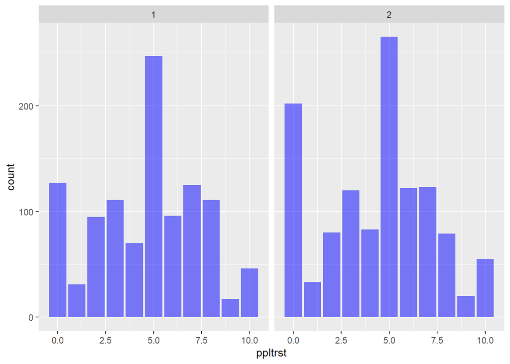

```r
# Completar aquí
ess_data_ES |>
  ggplot(aes(x = ppltrst)) +
  geom_bar(aes(y = after_stat(count)), fill = "blue", alpha = .5) +
  facet_grid(~ gndr)
```

```r
# Fin Completar aquí
```

```r
#  nada que completar
ess_data_ES_long <- ess_data_ES  |>
    pivot_longer(
        cols = starts_with("ppl"),
        names_to = "variable",
        values_to = "valor"
    )
head(ess_data_ES_long)
```

```
# A tibble: 6 × 5
   idno cntry  gndr variable valor
  <dbl> <chr> <dbl> <chr>    <dbl>
1 10009 ES        1 ppltrst      5
2 10009 ES        1 pplfair      5
3 10009 ES        1 pplhlp       5
4 10032 ES        1 ppltrst      5
5 10032 ES        1 pplfair      6
6 10032 ES        1 pplhlp       4
```

Por ejemplo, el primer entrevistado español contestó con un 5 a las tres preguntas.

Ahora podemos hacer la matriz siguiente:

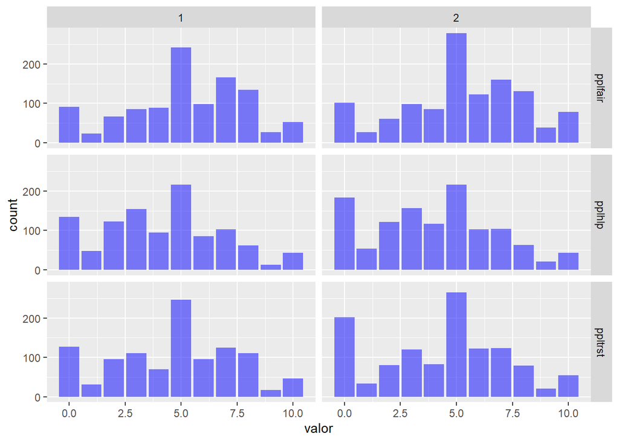

```r
# Completar aquí
ess_data_ES_long |>
    ggplot(aes(x = valor)) +
    geom_bar(aes(y = after_stat(count)), fill = "blue", alpha = .5) +
    facet_grid(variable ~ gndr)
```

```r
# Fin Completar aquí
```

**Para la estimación de la valoración promedio, un filtrado adicional**

Por los diagramas de barras anteriores, parece que una parte importante de los entrevistados contestan con un 0 a estas preguntas sobre su percepción de los demás. Puede corresponder a una reacción emocional, puesto que queremos obtener la valoración promedio y construir un intervalo de confianza usando un modelo normal, vamos además a eliminar los 0 del conjunto. De la misma manera, quitamos también los valores 10 del conjunto.  
PD: No se trata de un procedimiento muy justificado, es más para poder ilustrar la construcción de intervalos!

Eliminad los valores 0 y 10 en `ess_data_ES_long` para las variables `ppltrst`, `pplfair`, `pplhlp`

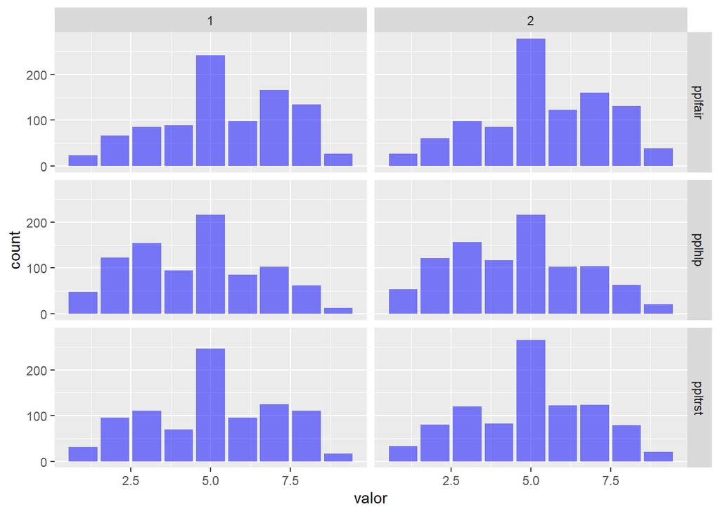

```r
# Completar aquí
ess_data_ES_long <- ess_data_ES_long |>
  filter(valor > 0, valor < 10)

# Fin Completar aquí
ess_data_ES_long |>
    ggplot(aes(x = valor)) +
    geom_bar(aes(y = after_stat(count)), fill = "blue", alpha = .5) +
    facet_grid(variable ~ gndr)
```

Podemos ahora volver a `ess_data_ES` en formato “ancho”, con `pivot_wider`, los valores que hemos filtrado se transformarán en valores faltantes, y no intervendrán en los cálculos

```r
# Nada que completar
ess_data_ES <- ess_data_ES_long  |>
    pivot_wider(
        names_from = variable,
        values_from = valor
    )
str_glue("El conjunto ess_data_ES tiene {nrow(ess_data_ES)} filas y {ncol(ess_data_ES)} columnas")
```

```
El conjunto ess_data_ES tiene 2090 filas y 6 columnas
```

```r
print("Número de datos faltantes por columnas:")
```

```
[1] "Número de datos faltantes por columnas:"
```

```r
ess_data_ES |>
    summarise(across(ppltrst:pplhlp, list(faltantes = \(x) sum(is.na(x))))) |>
    print()
```

```
# A tibble: 1 × 3
  ppltrst_faltantes pplfair_faltantes pplhlp_faltantes
              <int>             <int>            <int>
1               262               156              236
```

**`pivot_wider`**

Para esta última operación con `pivot_wider`, nos hemos aprovechado del hecho de disponer de una columna (`idno`) que identificaba el entrevistado de manera única.

## Cálculo de un intervalo de confianza para la valoración promedio

**Distribucion muestral para la media**

Si consideramos $X\sim\mathcal{N}(\mu_X, \sigma_X^2)$ m.a.s de $X$ y $\sigma$ desconocida tenemos:

$$\frac {\overline{X} -\mu_X}{S_n/\sqrt{n}}\sim {t}_{n-1}.$$

Vamos a calcular un intervalo de confianza para la valoración promedio para cada una de las tres variables, para los datos de España

Empezad por definir una función `calcular_error_ic` que admita como parámetros un vector `x`, un valor `alpha` entre 0 y 1, y que devuelva el margen de error asociado a un IC para $\mu$, suponiendo que `x` es una realización de una m.a.s de un $\mathcal{N}(\mu, \sigma^2)$, con $\sigma$ desconocida.

```r
# Completar aquí
calcular_error_ic <- function(x, alpha) {
  # Tamaño de la muestra
  n <- length(x)

  # Media y desviación estándar de la muestra
  media <- mean(x)
  sd_muestra <- sd(x, na.rm = TRUE)

  # Error estándar de la media
  error_estandar <- sd_muestra / sqrt(n)

  # Valor crítico t para el nivel de confianza (1 - alpha)
  t_critico <- qt(1 - alpha / 2, df = n - 1)

  # Margen de error
  margen_error <- t_critico * error_estandar

  return(margen_error)
}


# Fin Completar aquí
x <- c(5.52, 6.02, 4.75, 9.29, 2.91, 4.25, 4.87, 4.72, 3.51, 7.95)
calcular_error_ic(x, 0.05)
```

```
[1] 1.396311
```

Usando `summarise` y `across` como en la primera parte, obtened un tibble que contenga para cada una de las tres variables `ppltrst`, `pplfair`, `pplhlp`, la media y el margen de error al 95% del IC correspondiente.

```r
# Completar aquí
library(dplyr)

# Calcular media y margen de error para cada variable en un tibble
resultados <- ess_data_ES |>
  summarise(
    across(
      c(ppltrst, pplfair, pplhlp),
      list(
        media = ~ mean(.x, na.rm = TRUE),
        error = ~ calcular_error_ic(.x, 0.05)
      ),
      .names = "{col}_{fn}"
    )
  )

resultados
```

```
# A tibble: 1 × 6
  ppltrst_media ppltrst_error pplfair_media pplfair_error pplhlp_media
          <dbl>         <dbl>         <dbl>         <dbl>        <dbl>
1          5.02        0.0851          5.42        0.0845         4.54
# ℹ 1 more variable: pplhlp_error <dbl>
```

```r
# Fin Completar aquí
```

Podemos ahora distinguir los géneros y obtener las mismas columnas:

```r
# Completar aquí
resultados_por_genero <- ess_data_ES |>
  group_by(gndr) |>
  summarise(
    across(
      c(ppltrst, pplfair, pplhlp),
      list(
        media = ~ mean(.x, na.rm = TRUE),
        error = ~ calcular_error_ic(.x, 0.05)
      ),
      .names = "{col}_{fn}"
    )
  )

resultados_por_genero
```

```
# A tibble: 2 × 7
   gndr ppltrst_media ppltrst_error pplfair_media pplfair_error pplhlp_media
  <dbl>         <dbl>         <dbl>         <dbl>         <dbl>        <dbl>
1     1          5.05         0.126          5.42         0.123         4.52
2     2          4.99         0.115          5.42         0.117         4.56
# ℹ 1 more variable: pplhlp_error <dbl>
```

```r
# Fin Completar aquí
```

# Comparación de las respuestas a dos preguntas.

Queremos comprobar si hay diferencias entre las respuestas de los entrevistados a la pregunta `ppltrst` (“¿Diría usted que, por lo general, se puede confiar en la mayoría de la gente, o que nunca se es lo bastante prudente en el trato con los demás?”) y a la pregunta `pplfair` (“¿Cree que la mayoría de la gente intentaría aprovecharse de usted si pudiera, o que sería honrada con usted?”.

## Exploración gráfica

Representad gráficamente las respuestas a la pregunta `pplfair` en función de las respuestas a la pregunta `ppltrst` para España.

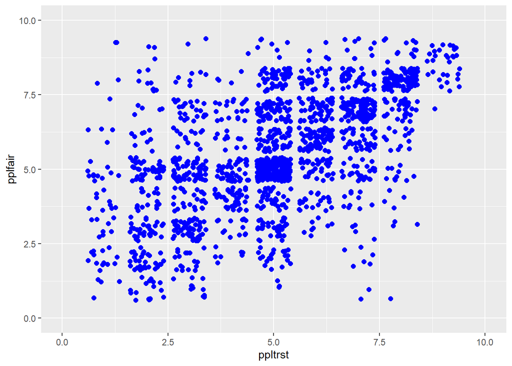

```r
# Completar aquí

ess_data_ES |>
  ggplot(aes(x = ppltrst, y = pplfair)) +
  geom_jitter(shape = 21, color = "blue", fill = "blue", size = 2) +
  xlim(0, 10) +
  ylim(0, 10)
```

```r
# Fin Completar aquí
```

**Para visualizar mejor:**

Hemos usado `geom_jitter` que es parecido a `geom_point` pero que mueve cada punto un poquito de manera aleatoria, lo que permite ver mejor al evitar los solapamientos. (podéis probar con `geom_point` para ver la diferencia

Por lo que vemos, y como era de esperar, las respuestas a las dos preguntas no son independientes. Para compararlas, vamos a hacer un intervalo de confianza para su diferencia.

Obtened un intervalo de confianza al 95% para el promedio de la diferencia entre la respuesta a `pplfair` y `ppltrst`, desglosando el resultado por género.

```r
# Completar aquí

ess_data_ES <- ess_data_ES |>
  mutate(diferencia = pplfair - ppltrst)

intervalo_confianza <- ess_data_ES |>
  group_by(gndr) |>
  summarise(
    media_diferencia = mean(diferencia, na.rm = TRUE),
    margen_error = calcular_error_ic(diferencia, 0.05)
  ) |>
  mutate(
    limite_inferior = media_diferencia - margen_error,
    limite_superior = media_diferencia + margen_error,
  )

intervalo_confianza
```

```
# A tibble: 2 × 5
   gndr media_diferencia margen_error limite_inferior limite_superior
  <dbl>            <dbl>        <dbl>           <dbl>           <dbl>
1     1            0.425        0.108           0.317           0.533
2     2            0.526        0.111           0.416           0.637
```

```r
# Fin Completar aquí
```

**Qué concluis?**

Hay una diferencia entre la valoración a las dos preguntas?

# Diferencia entre las valoraciones a la misma pregunta por hombres y mujeres.

Vamos a construir un IC para la diferencia de las valoraciones promedio a la pregunta `ppltrst` entre hombres y mujeres.

**Distribuciones muestrales para dos medias.**

Si consideramos dos v.a $X\sim\mathcal{N}(\mu_X, \sigma_X^2)$ e $Y\sim\mathcal{N}(\mu_Y, \sigma_Y^2)$, independientes, y dos m.a.s de $X$ e $Y$, tenemos tres distribuciones muestrales:

- Si conocemos $\sigma_X$ y $\sigma_Y$,
  $$\frac {\overline{X_1}-\overline{X_2} -(\mu_1-\mu_2)}{\sqrt{\frac {\sigma_1^2}{n_1}+\frac {\sigma_2^2}{n_2}}}\sim\mathcal{N}(0,1).$$
- Si a la hora de la modelización hemos supuesto $\sigma_X^2=\sigma_Y^2$, podemos estimar la varianza común $\sigma^2$ utilizando las dos muestras. Introducimos
  $$S_0^2=\frac{(n_X-1)S_X^2+(n_Y-1)S_Y^2}{n_X+n_Y-2}$$
  Utilizaremos la distribución
  $$\frac {\overline{X}-\overline{Y} -(\mu_X-\mu_Y)}{\sqrt{S_0^2(\frac {1}{n_X}+\frac {1}{n_Y})}}\sim {t}_{n_X+n_Y-2}.$$
- Si NO se suponen iguales, en este caso, no se conoce de manera exacta la distribución muestral del estadístico natural $\frac {\overline{X}-\overline{X} -(\mu_X-\mu_Y)}{\sqrt{\frac {S_X^2}{n_X}+\frac {S_Y^2}{n_Y}}}$. Sin embargo, se puede utilizar la aproximación siguiente:
  $$\frac {\overline{X}-\overline{Y} -(\mu_X-\mu_Y)}{\sqrt{\frac {S_X^2}{n_X}+\frac {S_Y^2}{n_Y}}}\sim t_k,\quad\mbox{donde $k=\inf(n_X-1,n_Y-1).$}$$

Definid una función que se llame `calcular_error_diferencia` que admite como argumentos un vector `x`, un vector `y`, el nivel de riesgo `alpha` y un booleano `varianzas_iguales`, que devuelva el margen de error del IC con nivel de confianza $100 \times (1 - \alpha)$ para la diferencia de medias $\mu_X - \mu_Y$.

```r
# Completar aquí
calcular_error_diferencia <- function(x, y, alpha, varianzas_iguales  = TRUE) {
  n_x <- length(x)
  n_y <- length(y)
  media_x <- mean(x, na.rm = TRUE)
  media_y <- mean(y, na.rm = TRUE)
  sd_x <- sd(x, na.rm = TRUE)
  sd_y <- sd(y, na.rm = TRUE)

  if (varianzas_iguales) {
    # Estimación de varianza común
    s0 <- sqrt(((n_x - 1) * sd_x^2 + (n_y -1) * sd_y^2) / (n_x + n_y - 2))
    error_estandar <- s0 * sqrt(1 / n_x + 1 / n_y)
    grados_libertad <- n_x + n_y - 2
  } else {
    # Varianzas diferentes
    error_estandar <- sqrt((sd_x^2 / n_x) + (sd_y^2 / n_y))
    grados_libertad <- min(n_x - 1, n_y - 1)
  }

  # Valor crítico de t para el nivel de confianza
  t_critico <- qt(1 - alpha / 2, df = grados_libertad)

  # Margen de error
  margen_error <- t_critico * error_estandar

  return(margen_error)
}

# Fin Completar aquí
x <- c(5.52, 6.02, 4.75, 9.29, 2.91, 4.25, 4.87, 4.72, 3.51, 7.95)
y <- c(7.81, 8.90, 6.72, 9.75, 4.13, 6.31, 3.66, 6.91, 8.40, 5.74)
calcular_error_diferencia(x, y, 0.05, varianzas_iguales = FALSE)
```

```
[1] 1.985635
```

Para España, obtened el IC al 95% para la diferencia entre las valoraciones promedio de hombres y mujeres para la pregunta `ppltrst`, sin suponer las varianzas iguales.

```r
# Completar aquí
# Filtrar los datos para obtener las respuestas de hombres y mujeres a la pregunta 'ppltrst'
mu_hombres <- ess_data_ES |> filter(gndr == 1) |> pull(ppltrst)
mu_mujeres <- ess_data_ES |> filter(gndr == 2) |> pull(ppltrst)

# Calcular la diferencia de medias y el margen de error para el IC al 95%
media_diferencia <- mean(mu_hombres, na.rm = TRUE) - mean(mu_mujeres, na.rm = TRUE)
margen_error <- calcular_error_diferencia(mu_hombres, mu_mujeres, 0.05, varianzas_iguales = FALSE)

str_glue("El intervalo mu_hombres - mu_mujers es {round(media_diferencia, 4)} ± {round(margen_error, 4)}")
```

```
El intervalo mu_hombres - mu_mujers es 0.0618 ± 0.1707
```

```r
# Fin Completar aquí
```

## Suponiendo las varianzas iguales.

Obtened la varianza para las respuestas a la pregunta `ppltrst`, desglosando por género.

```r
# Completar aquí
varianza_por_genero <- ess_data_ES |>
  group_by(gndr) |>
  summarise(varianza_ppltrst = var(ppltrst, na.rm = TRUE))

varianza_por_genero
```

```
# A tibble: 2 × 2
   gndr varianza_ppltrst
  <dbl>            <dbl>
1     1             4.13
2     2             3.74
```

```r
# Fin Completar aquí
```

Los valores son parecidos, para confirmarlo, podemos construir un IC para el ratio de varianzas. Sabemos que, en el caso de normales, tenemos

$$\frac{(n_X-1)S_{X}^2/\sigma_X^2}{(n_Y-1)S_{Y}^2/\sigma_Y^2}\sim F_{n_X-1, n_Y-1}.$$

Definid una función `calcular_ic_cociente_varianzas` que admite como argumentos un vector `x`, un vector `y`, el nivel de riesgo `alpha`, y que devuelva un tibble con dos columnas, una llamada `izq` y otra llamada `der` que contengan los dos extremos del IC para el cociente de las varianzas.

```r
# Completar aquí
calcular_ic_cociente_varianzas <- function(x, y, alpha) {
  n_x <- length(x)
  n_y <- length(y)
  var_x <- var(x, na.rm = TRUE)
  var_y <- var(y, na.rm = TRUE)

  # Calcular el cociente de las variantes
  cociente_varianzas <- var_x / var_y

  # Calcular los valores críticos de la distribución F
  f_izq <- qf(alpha / 2, df1 = n_x - 1, df2 = n_y - 1)
  f_der <- qf(1 - alpha / 2, df1 = n_x - 1, df2 = n_y - 1)

  # Calcular los datos extremos del intervalo de confianza
  limite_izq <- cociente_varianzas / f_der
  limite_der <- cociente_varianzas / f_izq

  # Crear un tibble con los resultados
  tibble(izq = limite_izq, der = limite_der)
}

# Fin Completar aquí
x <- c(5.52, 6.02, 4.75, 9.29, 2.91, 4.25, 4.87, 4.72, 3.51, 7.95)
y <- c(7.81, 8.90, 6.72, 9.75, 4.13, 6.31, 3.66, 6.91, 8.40, 5.74)
calcular_ic_cociente_varianzas(x, y, 0.05)
```

```
# A tibble: 1 × 2
    izq   der
  <dbl> <dbl>
1 0.243  3.94
```

Para España, obtened el IC al 95% para el cociente de las varianzas de las respuestas de hombres y mujeres para la pregunta `ppltrst`.

```r
# Completar aquí
# Calcular el intervalo de confianza para el cociente de las varianzas
ic_cociente_varianzas <- calcular_ic_cociente_varianzas(mu_hombres, mu_mujeres, 0.05)

ic_cociente_varianzas
```

```
# A tibble: 1 × 2
    izq   der
  <dbl> <dbl>
1 0.979  1.25
```

```r
# Fin Completar aquí
```

**Qué concluis?**

Volved a calcular el IC para España al 95% para la diferencia entre las valoraciones promedio de hombres y mujeres para la pregunta `ppltrst`, pero suponiendo ahora las varianzas iguales.

```r
# Completar aquí
n_hombres <- length(mu_hombres)
n_mujeres <- length(mu_mujeres)
var_hombres <- var(mu_hombres, na.rm = TRUE)
var_mujeres <- var(mu_mujeres, na.rm = TRUE)
varianza_comun <- ((n_hombres - 1) * var_hombres + (n_mujeres - 1) * var_mujeres) / (n_hombres + n_mujeres - 2)

# Calcular el margen de error para el IC al 95%
error_estandar <- sqrt(varianza_comun * (1 / n_hombres + 1 / n_mujeres))
t_critico <- qt(0.975, df = n_hombres + n_mujeres - 2)
margen_error <- t_critico * error_estandar

str_glue("El intervalo mu_hombres - mu_mujers es {round(media_diferencia, 4)} ± {round(margen_error, 4)}")
```

```
El intervalo mu_hombres - mu_mujers es 0.0618 ± 0.1702
```

```r
# Fin Completar aquí
```

**Qué concluis?**

Comparad con el IC obtenido si no suponemos las varianzas iguales.

# Parte opcional: consideramos los datos desde 2002

Cargad todos los ficheros correspondientes al ESS, y obtened, para España, las mismas columnas pero desglosando por género y por año.  
Para ello, empezad por escribid una función `cargar_ESS_file` que coja el nombre del fichero y devuelva un tibble preparado, con los datos filtrados tal como lo hemos visto para 2020

```r
# Completar aquí
cargar_ESS_file <- function(file_name) {
  ess_data <- read_csv(unz(ZIP_FILE, file_name), col_select = c("idno", "cntry", "gndr", "ppltrst", "pplfair", "pplhlp"))

  ess_data <- ess_data |>
    filter(
      cntry == "ES",
      gndr %in% c(1,2),
      ppltrst <= 10,
      pplfair <= 10,
      pplhlp <= 10
    )

  return(ess_data)
}

# Fin Completar aquí
glimpse(cargar_ESS_file("ESS1e06_6.csv"))
```

```
Rows: 1,675
Columns: 6
$ idno    <dbl> 2, 5, 8, 13, 15, 22, 23, 25, 27, 31, 36, 37, 38, 41, 42, 43, 4…
$ cntry   <chr> "ES", "ES", "ES", "ES", "ES", "ES", "ES", "ES", "ES", "ES", "E…
$ gndr    <dbl> 2, 1, 1, 1, 1, 1, 2, 1, 2, 2, 2, 1, 2, 1, 2, 1, 2, 2, 1, 1, 1,…
$ ppltrst <dbl> 5, 3, 5, 2, 2, 8, 4, 7, 8, 5, 1, 3, 3, 5, 3, 6, 4, 7, 3, 5, 8,…
$ pplfair <dbl> 4, 3, 3, 5, 3, 7, 7, 7, 8, 8, 5, 2, 2, 4, 3, 2, 5, 5, 3, 3, 8,…
$ pplhlp  <dbl> 5, 3, 8, 4, 2, 5, 3, 4, 5, 4, 2, 2, 4, 3, 3, 4, 3, 7, 2, 3, 5,…
```

Podéis ahora usar `map_dfr` para crear un único dataframe que contenga los datos de todos los años. Pasaremos a `map_dfr` una lista cuyos nombres son los años, y usaremos el argumento `.id` de `map_dfr`.

```r
ESS_FILE_NAMES <- c(
    "2002" = "ESS1e06_6.csv",
    "2004" = "ESS2e03_6.csv",
    "2006" = "ESS3e03_7.csv",
    "2008" = "ESS4e04_5.csv",
    "2010" = "ESS5e03_4.csv",
    "2012" = "ESS6e02_5.csv",
    "2014" = "ESS7e02_2.csv",
    "2016" = "ESS8e02_2.csv",
    "2018" = "ESS9e03_1.csv",
    "2020" = "ESS10SC.csv"
)
# Completar aquí
ess_data <- map_dfr(ESS_FILE_NAMES, cargar_ESS_file, .id = "year")
# Fin Completar aquí
glimpse(ess_data)
```

```
Rows: 19,155
Columns: 7
$ year    <chr> "2002", "2002", "2002", "2002", "2002", "2002", "2002", "2002"…
$ idno    <dbl> 2, 5, 8, 13, 15, 22, 23, 25, 27, 31, 36, 37, 38, 41, 42, 43, 4…
$ cntry   <chr> "ES", "ES", "ES", "ES", "ES", "ES", "ES", "ES", "ES", "ES", "E…
$ gndr    <dbl> 2, 1, 1, 1, 1, 1, 2, 1, 2, 2, 2, 1, 2, 1, 2, 1, 2, 2, 1, 1, 1,…
$ ppltrst <dbl> 5, 3, 5, 2, 2, 8, 4, 7, 8, 5, 1, 3, 3, 5, 3, 6, 4, 7, 3, 5, 8,…
$ pplfair <dbl> 4, 3, 3, 5, 3, 7, 7, 7, 8, 8, 5, 2, 2, 4, 3, 2, 5, 5, 3, 3, 8,…
$ pplhlp  <dbl> 5, 3, 8, 4, 2, 5, 3, 4, 5, 4, 2, 2, 4, 3, 3, 4, 3, 7, 2, 3, 5,…
```

Después de transformar `year` en numérico, obtened para cada año y desglosando por género la media y el margen de error para cada una de las tres variables

```r
# Completar aquí
resultados <- ess_data |>
  group_by(gndr, year) |>
  summarise(
    across(
      c(ppltrst, pplfair, pplhlp),
      list(
        media = ~mean(.x, na.rm = TRUE),
        error = ~ calcular_error_ic(.x, 0.05)
      ),
      .names = "{col}_{fn}"
    )
  )
resultados
```

```
# A tibble: 20 × 8
# Groups:   gndr [2]
    gndr year  ppltrst_media ppltrst_error pplfair_media pplfair_error
   <dbl> <chr>         <dbl>         <dbl>         <dbl>         <dbl>
 1     1 2002           4.96         0.156          5.20         0.155
 2     1 2004           4.99         0.145          5.23         0.143
 3     1 2006           5.19         0.129          5.38         0.127
 4     1 2008           4.91         0.112          5.30         0.108
 5     1 2010           5.23         0.124          5.30         0.118
 6     1 2012           5.13         0.136          5.35         0.139
 7     1 2014           4.96         0.130          5.29         0.124
 8     1 2016           5            0.142          5.33         0.137
 9     1 2018           5.27         0.139          5.52         0.140
10     1 2020           4.67         0.163          5.19         0.157
11     2 2002           4.77         0.152          5.20         0.148
12     2 2004           4.79         0.159          5.18         0.156
13     2 2006           5.04         0.127          5.45         0.124
14     2 2008           4.89         0.110          5.26         0.106
15     2 2010           5.05         0.126          5.27         0.118
16     2 2012           5.12         0.139          5.46         0.136
17     2 2014           4.72         0.141          5.34         0.144
18     2 2016           4.99         0.141          5.50         0.131
19     2 2018           4.99         0.157          5.57         0.152
20     2 2020           4.37         0.161          5.25         0.153
# ℹ 2 more variables: pplhlp_media <dbl>, pplhlp_error <dbl>
```

```r
# Fin Completar aquí
```